# Exploration

```r
# Load packages
library(tidyverse)
```

```r
library(ggplot2)
library(readxl)
library(lubridate)
library(broom)
library(viridis)
library(tsModel)
# Global options
knitr::opts_chunk$set(echo = TRUE, warning = FALSE, message = FALSE)
```

# 1 Introduction

This contains all code used to explore the datasets found in the `/CleanData` directory, which were previously generated in the `/01_Scripts/Cleaning.rmd` file.

The purpose of this exploration is to

1. Explore descriptive characteristics of each dataset, including average trends and visualizing how deaths change before/after interruption point

and

2. Conduct exploratory analysis where we build up models, starting from simple linear to increasing complexity (incorporating seasonality, etc.). We decided a priori to use an ARIMA specification for this analysis, but we want to investigate what the model may look like in other forms as well.

# 2 Descriptive Analysis

We are going to get some descriptive stats for our 3 analyses of interest, using June as our interruption point.

## 2.1 1. Reproductive-aged Assault Mortality

Next, we will explore just reproductive-aged deaths by assault.

**How many deaths occurred among females? Males? Which months had highest counts?**

```r
#female death count
monthly_f %>%
  summarize(n_deaths = sum(Deaths, na.rm = TRUE))
```

```
##   n_deaths
## 1     1525
```

```r
#male death count
monthly_m %>%
  summarize(n_deaths = sum(Deaths, na.rm = TRUE))
```

```
##   n_deaths
## 1     7127
```

```r
#highest counts female
monthly_f %>%
  arrange(desc(Deaths)) %>%
  select(month_year, Deaths) %>%
  slice(1:3)
```

```
##   month_year Deaths
## 1 2021-09-01     35
## 2 2023-12-01     34
## 3 2020-08-01     32
```

```r
#highest count male
monthly_m %>%
  arrange(desc(Deaths)) %>%
  select(month_year, Deaths) %>%
  slice(1:3)
```

```
##   month_year Deaths
## 1 2020-12-01    137
## 2 2021-05-01    137
## 3 2020-11-01    136
```

```r
#descriptive stats
monthly_all %>%
  group_by(sex) %>%
  summarise(
    n_months      = n(),
    total_deaths  = sum(Deaths, na.rm = TRUE),
    monthly_mean  = mean(Deaths, na.rm = TRUE),
    monthly_sd    = sd(Deaths, na.rm = TRUE),
    .groups = "drop"
  )
```

```
## # A tibble: 2 × 5
##   sex    n_months total_deaths monthly_mean monthly_sd
##   <chr>     <int>        <int>        <dbl>      <dbl>
## 1 Female       72         1525         21.2       5.59
## 2 Male         72         7127         99.0      22.3
```

**Plotting both**

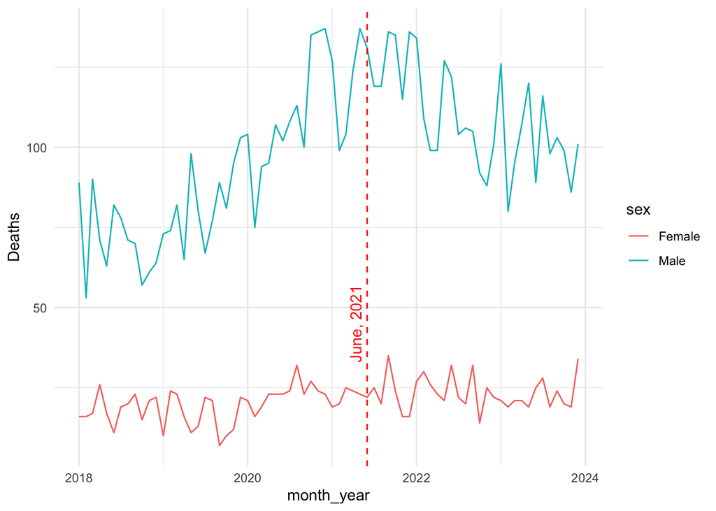

```r
monthly_all <- monthly_all %>%
   mutate(month_year = as.Date(month_year))

vline_date <- as.Date("2021-06-01")

ggplot(monthly_all) +
  geom_line(aes(x = month_year, y = Deaths, color = sex)) +
  geom_vline(xintercept = vline_date, linetype = "dashed", color = "red") +
  annotate("text",
           x = vline_date,
           y = 45,
           label = "June, 2021",
           angle = 90,
           vjust = -0.5,
           color = "red") +
  theme_minimal()
```

## 2.2 2. All-age Assault Mortality

We will investigate assault mortality among all ages, not just reproductive.

```r
m_all_age %>%
  summarise(
    n_months      = n(),
    total_deaths  = sum(Deaths, na.rm = TRUE),
    monthly_mean  = mean(Deaths, na.rm = TRUE),
    monthly_sd    = sd(Deaths, na.rm = TRUE),
    .groups = "drop"
  )
```

```
##   n_months total_deaths monthly_mean monthly_sd
## 1       72         9651     134.0417   26.52102
```

```r
f_all_age %>%
  summarise(
    n_months      = n(),
    total_deaths  = sum(Deaths, na.rm = TRUE),
    monthly_mean  = mean(Deaths, na.rm = TRUE),
    monthly_sd    = sd(Deaths, na.rm = TRUE),
    .groups = "drop"
  )
```

```
##   n_months total_deaths monthly_mean monthly_sd
## 1       72         2564     35.61111   7.986883
```

**Plotting both**

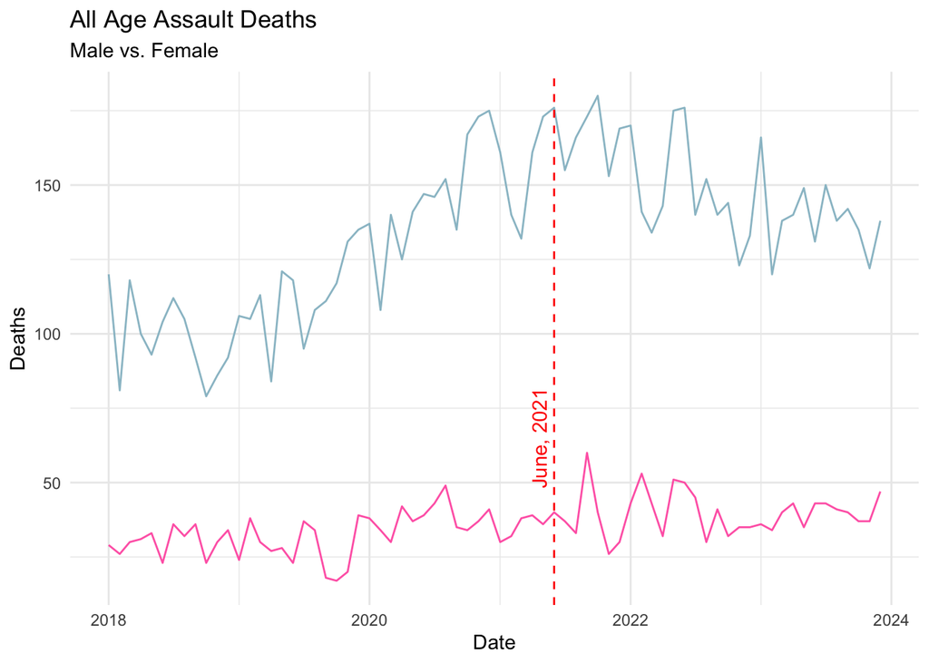

```r
ggplot() +
  geom_line(data = f_all_age,
            aes(x = month_year, y = Deaths),
            color = "hotpink") +
  geom_line(data = m_all_age,
            aes(x = month_year, y = Deaths),
            color = "lightblue3") +
  labs(x = "Date",
       y = "Deaths") +
  theme_minimal() +
  theme(axis.text.x = element_text(angle = 45, hjust = 1))+
  geom_vline(xintercept = vline_date, linetype = "dashed", color = "red") +
  annotate("text",
           x = vline_date,
           y = 65,
           label = "June, 2021",
           angle = 90,
           vjust = -0.5,
           color = "red") +
  theme_minimal()+
  ggtitle("All Age Assault Deaths",
          subtitle= "Male vs. Female")
```

## 2.3 3. All-Cause, COVID

**How many deaths occurred over the study period that were all cause? By sex?**

```r
f_all %>%
  summarise(
    n_months      = n(),
    total_deaths  = sum(Deaths, na.rm = TRUE),
    monthly_mean  = mean(Deaths, na.rm = TRUE),
    monthly_sd    = sd(Deaths, na.rm = TRUE),
    .groups = "drop"
  )
```

```
##   n_months total_deaths monthly_mean monthly_sd
## 1       72        33290     462.3611   96.00371
```

```r
m_all %>%
  summarise(
    n_months      = n(),
    total_deaths  = sum(Deaths, na.rm = TRUE),
    monthly_mean  = mean(Deaths, na.rm = TRUE),
    monthly_sd    = sd(Deaths, na.rm = TRUE),
    .groups = "drop"
  )
```

```
##   n_months total_deaths monthly_mean monthly_sd
## 1       72        72089     1001.236   209.6633
```

Females had 33,290 over the study period. Males had 72,089 deaths. 105,379 total deaths occurred among reproductive aged-texas residents from January 2018 to Dec 2023.

**What months had the most deaths for males and females? What were the top 3 death counts?**

```r
f_all %>%
  arrange(desc(Deaths)) %>%
  select(month_year, Deaths) %>%
  slice(1:3)
```

```
##   month_year Deaths
## 1 2021-09-01    859
## 2 2021-08-01    826
## 3 2021-10-01    671
```

```r
m_all %>%
  arrange(desc(Deaths)) %>%
  select(month_year, Deaths) %>%
  slice(1:3)
```

```
##   month_year Deaths
## 1 2021-09-01   1887
## 2 2021-08-01   1657
## 3 2021-10-01   1400
```

For both males and females, the months with the highest death counts were August, September, and October of 2021. Deaths were higher among men than females for these months.

**How many female deaths were due to covid? For which months? What do they look like plotted against each other?**

```r
#deaths due to covid
covid %>%
  summarise(
    n_months      = n(),
    total_deaths  = sum(Deaths, na.rm = TRUE),
    monthly_mean  = mean(Deaths, na.rm = TRUE),
    monthly_sd    = sd(Deaths, na.rm = TRUE),
    .groups = "drop"
  )
```

```
##   n_months total_deaths monthly_mean monthly_sd
## 1       72         2291     40.91071    77.5824
```

```r
#which months
covid %>%
  filter(!is.na(Deaths)& Deaths != 0)
```

```
##    Deaths month_year time
## 1      15 2020-04-01   28
## 2      10 2020-05-01   29
## 3      29 2020-06-01   30
## 4     116 2020-07-01   31
## 5      65 2020-08-01   32
## 6      45 2020-09-01   33
## 7      51 2020-10-01   34
## 8      71 2020-11-01   35
## 9      90 2020-12-01   36
## 10    116 2021-01-01   37
## 11     84 2021-02-01   38
## 12     58 2021-03-01   39
## 13     38 2021-04-01   40
## 14     40 2021-05-01   41
```

[output cut: 16 more lines]

```r
#deaths without covid
f_minus_covid %>%
 summarise(
    n_months      = n(),
    total_deaths  = sum(Deaths, na.rm = TRUE),
    monthly_mean  = mean(Deaths, na.rm = TRUE),
    monthly_sd    = sd(Deaths, na.rm = TRUE),
    .groups = "drop"
  )
```

```
##   n_months total_deaths monthly_mean monthly_sd
## 1       72        30999     430.5417   49.39691
```

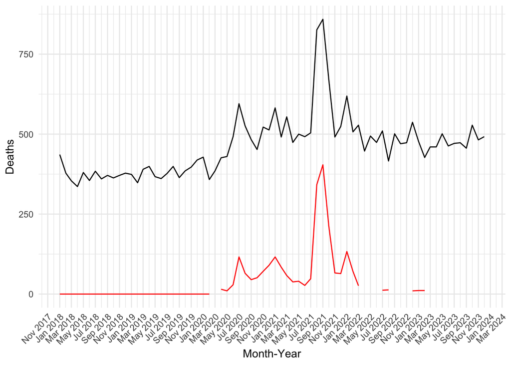

```r
#plotting them both side by side
f_all <- f_all %>%
  mutate(month_year = as.Date(month_year))

covid <- covid %>%
  mutate(month_year = as.Date(month_year))

ggplot() +
  geom_line(data = f_all,
            aes(x = month_year, y = Deaths),
            color = "black") +
  geom_line(data = covid,
            aes(x = month_year, y = Deaths),
            color = "red") +
 scale_x_date(date_breaks = "2 months", date_labels = "%b %Y")+
  labs(x = "Month-Year",
       y = "Deaths") +
  theme_minimal() +
  theme(axis.text.x = element_text(angle = 45, hjust = 1))
```

It’s pretty clear here that a big portion of the death spike we see is from a covid outbreak in texas.

**Let’s plot and describe the deaths that are all causes, EXCEPT COVID deaths.**

```r
#how many deaths over study period?
f_minus_covid %>%
  summarize(n_deaths = sum(Deaths, na.rm = TRUE))
```

```
##   n_deaths
## 1    30999
```

```r
#largest death counts?
f_minus_covid %>%
  arrange(desc(Deaths)) %>%
  select(month_year, Deaths) %>%
  slice(1:3)
```

```
##   month_year Deaths
## 1 2023-10-01    528
## 2 2022-12-01    527
## 3 2022-03-01    502
```

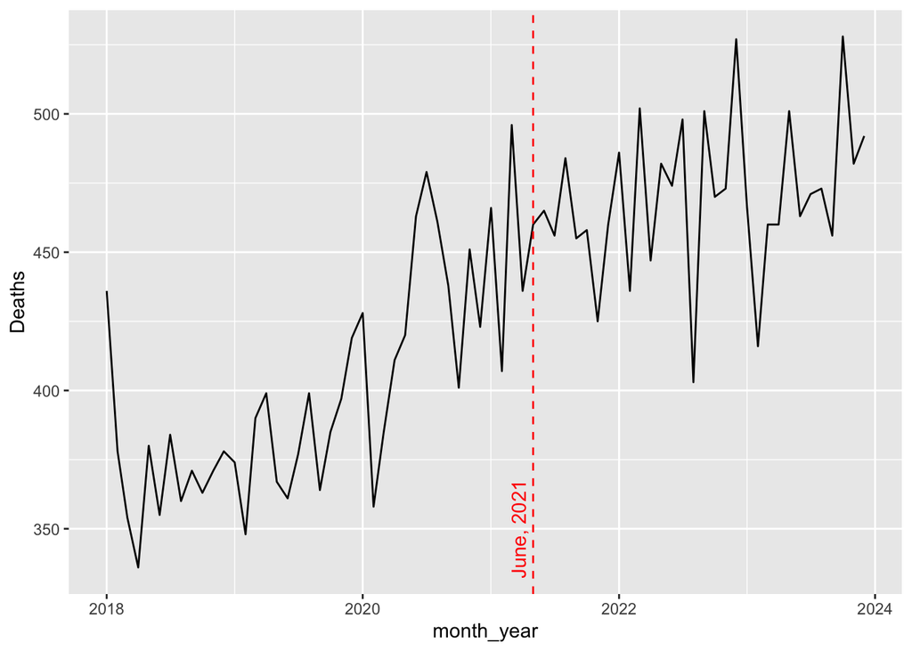

```r
#plotting
f_minus_covid <- f_minus_covid %>%
  mutate(month_year = as.Date(month_year))

vline_date <- as.Date("2021-05-01")

ggplot(f_minus_covid)+
geom_line(data = f_minus_covid,
            aes(x = month_year, y = Deaths),
            color = "black") +
   geom_vline(xintercept = vline_date, linetype = "dashed", color = "red") +
  annotate("text",
           x = vline_date,
           y = 350, # slightly above top
           label = "June, 2021",
           angle = 90,
           vjust = -0.5,
           color = "red")
```

It does not appear as though these results are unexpected. No outliers are likely.

## 2.4 4. Racial breakdown

**Summary Stats by Race**

```r
racial_minus_covid %>%
  group_by(race_eth) %>%
  summarise(
    n_months      = n(),
    total_deaths  = sum(Deaths, na.rm = TRUE),
    monthly_mean  = mean(Deaths, na.rm = TRUE),
    monthly_sd    = sd(Deaths, na.rm = TRUE),
    .groups = "drop"
  )
```

```
## # A tibble: 4 × 5
##   race_eth                  n_months total_deaths monthly_mean monthly_sd
##   <chr>                        <int>        <int>        <dbl>      <dbl>
## 1 Asian                           35          444         12.7       3.24
## 2 Black or African American       72         6691         92.9      15.6
## 3 Hispanic                        72        10095        140.       19.9
## 4 White                           72        13413        186.       23.0
```

**Highest Death Count Months**

```r
racial_minus_covid %>%
  arrange(desc(Deaths)) %>%
  group_by(race_eth) %>%
  slice(1:3)
```

```
## # A tibble: 12 × 3
## # Groups:   race_eth [4]
##    race_eth                  month_year Deaths
##    <chr>                     <date>      <int>
##  1 Asian                     2020-02-01     23
##  2 Asian                     2022-09-01     21
##  3 Asian                     2021-09-01     20
##  4 Black or African American 2023-05-01    126
##  5 Black or African American 2022-01-01    116
##  6 Black or African American 2021-05-01    115
##  7 Hispanic                  2022-12-01    189
##  8 Hispanic                  2021-08-01    178
##  9 Hispanic                  2022-09-01    170
## 10 White                     2022-07-01    247
## 11 White                     2021-03-01    238
## 12 White                     2023-10-01    235
```

**Plotting racial trends**

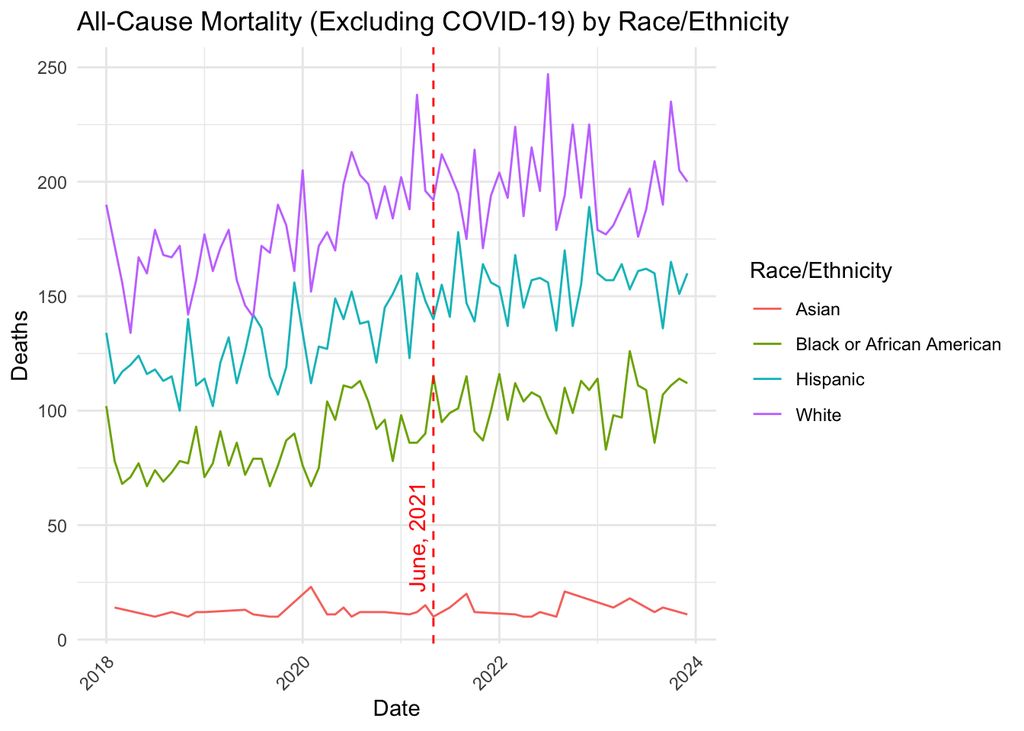

```r
ggplot(racial_minus_covid,
       aes(x = month_year, y = Deaths, color = race_eth)) +
  geom_line() +
  labs(x = "Date",
       y = "Deaths",
       color = "Race/Ethnicity") +
  theme_minimal() +
  theme(axis.text.x = element_text(angle = 45, hjust = 1)) +
  geom_vline(xintercept = vline_date, linetype = "dashed", color = "red") +
  annotate("text",
           x = vline_date,
           y = 45,
           label = "June, 2021",
           angle = 90,
           vjust = -0.5,
           color = "red") +
  ggtitle("All-Cause Mortality (Excluding COVID-19) by Race/Ethnicity")
```

### 2.4.1 Annual Trends

It looks as though we do not have enough data populating for Native Hawaiian or Other Pacific islander. We are therefore going to just describe the annual trends for the other racial categories:

```r
racial_annual %>%
  filter(race_eth != "Native Hawaiian or Other Pacific Islander") %>%
  group_by(race_eth) %>%
  summarise(
    n_years      = n(),
    total_deaths  = sum(deaths, na.rm = TRUE),
    annual_mean  = mean(deaths, na.rm = TRUE),
    annual_sd    = sd(deaths, na.rm = TRUE),
    .groups = "drop"
  )
```

```
## # A tibble: 3 × 5
##   race_eth                  n_years total_deaths annual_mean annual_sd
##   <chr>                       <int>        <int>       <dbl>     <dbl>
## 1 Black or African American       7          590        84.3      15.4
## 2 Hispanic                        7          670        95.7      14.1
## 3 White                           7          438        62.6      17.9
```

# 3 Investigating Models

Next we are going to plot the forcing value (time) and the outcome (death count)

```r
#looking at range of dates
range(monthly_f$time)
```

```
## [1]  1 72
```

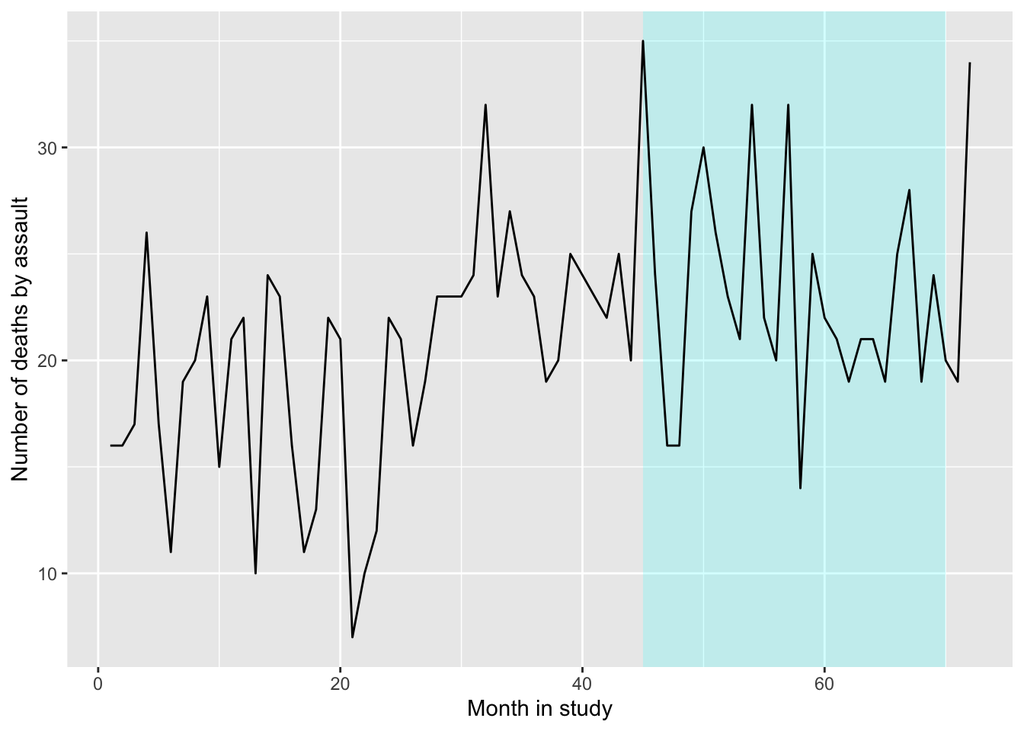

```r
ggplot()+
  geom_polygon(aes(c(45,70,70,45),
                   c(Inf, Inf, -Inf, -Inf)),
               fill = "cyan", alpha = 0.2)+
  geom_line(data = monthly_f, aes(time, Deaths))+
  labs(x = "Month in study",
       y = "Number of deaths by assault")
```

We want to investigate the death rate before and after the ban was implemented. To start, we are just going to use a simple poisson model.

```r
mod1 <- glm(Deaths ~ time ,
                      data = monthly_f,
                       family = poisson(link = "log"))
summary(mod1)
```

```
##
## Call:
## glm(formula = Deaths ~ time, family = poisson(link = "log"),
##     data = monthly_f)
##
## Coefficients:
##             Estimate Std. Error z value Pr(>|z|)
## (Intercept) 2.864409   0.054223  52.827  < 2e-16 ***
## time        0.005020   0.001236   4.061 4.88e-05 ***
## ---
## Signif. codes:  0 '***' 0.001 '**' 0.01 '*' 0.05 '.' 0.1 ' ' 1
##
## (Dispersion parameter for poisson family taken to be 1)
##
##     Null deviance: 109.603  on 71  degrees of freedom
## Residual deviance:  93.057  on 70  degrees of freedom
## AIC: 446.98
##
## Number of Fisher Scoring iterations: 4
```

```r
#introducing bill8
monthly_f <- monthly_f %>%
  mutate(bill8 = month_year > as.Date("2021-06-01"))

mod2 <- glm(
  Deaths ~ time + bill8,
  family = poisson(link = "log"),
  data = monthly_f
)

summary(mod2)
```

```
##
## Call:
## glm(formula = Deaths ~ time + bill8, family = poisson(link = "log"),
##     data = monthly_f)
##
## Coefficients:
##              Estimate Std. Error z value Pr(>|z|)
## (Intercept)  2.854646   0.063945  44.642   <2e-16 ***
## time         0.005616   0.002403   2.338   0.0194 *
## bill8TRUE   -0.028885   0.099774  -0.290   0.7722
## ---
## Signif. codes:  0 '***' 0.001 '**' 0.01 '*' 0.05 '.' 0.1 ' ' 1
##
## (Dispersion parameter for poisson family taken to be 1)
##
##     Null deviance: 109.603  on 71  degrees of freedom
## Residual deviance:  92.973  on 69  degrees of freedom
## AIC: 448.9
##
## Number of Fisher Scoring iterations: 4
```

```r
#extracting coefficient terms
mod2 %>%
  tidy()
```

```
## # A tibble: 3 × 5
##   term        estimate std.error statistic p.value
##   <chr>          <dbl>     <dbl>     <dbl>   <dbl>
## 1 (Intercept)  2.85      0.0639     44.6    0
## 2 time         0.00562   0.00240     2.34   0.0194
## 3 bill8TRUE   -0.0289    0.0998     -0.290  0.772
```

```r
#getting estimate of relative rate for group after bill vs. before

mod2 %>%
  tidy(conf.int = TRUE, exponentiate = TRUE) %>%
  filter(term == "bill8TRUE") %>%
  select(estimate, conf.low, conf.high)
```

```
## # A tibble: 1 × 3
##   estimate conf.low conf.high
##      <dbl>    <dbl>     <dbl>
## 1    0.972    0.799      1.18
```

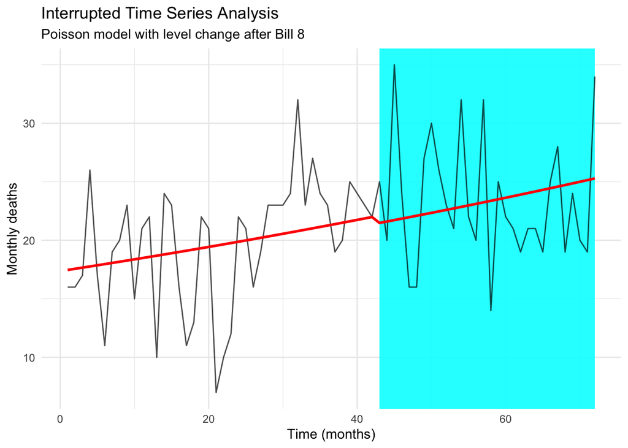

```r
#how to plot the interrupted ts

#saving augmented data from model
mod2_data <- augment(mod2, type.predict = "response") %>%
  mutate(
    observed = Deaths,
    fitted   = .fitted
  )
intervention_time <- min(monthly_f$time[monthly_f$bill8])

#ggplotting
ggplot(mod2_data, aes(x = time)) +
  #post-bill shading
   geom_rect(
    aes(
      xmin = intervention_time,
      xmax = max(time),
      ymin = -Inf,
      ymax = Inf
    ),
    fill = "cyan",
    alpha = 0.2,
    inherit.aes = FALSE
  ) +
  #observed death counts
   geom_line(aes(y = observed), alpha = 0.7) +
  #fit ITS line
  geom_line(aes(y = fitted), color = "red", linewidth = 1) +

  labs(
    x = "Time (months)",
    y = "Monthly deaths",
    title = "Interrupted Time Series Analysis",
    subtitle = "Poisson model with level change after Bill 8"
  ) +
  theme_minimal()
```

Looking at that first poisson model, there is no significance between groups. We expected that, however, as the poisson isn’t the most appropriate selection and our data has seasonality trends. We are now going to look into making this a nonlinear model.

```r
#making month_year a date var
monthly_f <- monthly_f %>%
  mutate(
    month_year = as.Date(month_year),
    month = month(month_year)
  )

#post-intervention slope term
intervention_time <- min(monthly_f$time[monthly_f$bill8])

monthly_f <- monthly_f %>%
  mutate(
    time_after = if_else(bill8, time - intervention_time + 1, 0)
  )

monthly_f %>%
  group_by(time_after) %>%
  slice(1:3)
```

```
## # A tibble: 33 × 6
## # Groups:   time_after [31]
##    Deaths month_year  time bill8 month time_after
##     <int> <date>     <int> <lgl> <dbl>      <dbl>
##  1     16 2018-01-01     1 FALSE     1          0
##  2     16 2018-02-01     2 FALSE     2          0
##  3     17 2018-03-01     3 FALSE     3          0
##  4     25 2021-07-01    43 TRUE      7          1
##  5     20 2021-08-01    44 TRUE      8          2
##  6     35 2021-09-01    45 TRUE      9          3
##  7     24 2021-10-01    46 TRUE     10          4
##  8     16 2021-11-01    47 TRUE     11          5
##  9     16 2021-12-01    48 TRUE     12          6
## 10     27 2022-01-01    49 TRUE      1          7
## # ℹ 23 more rows
```

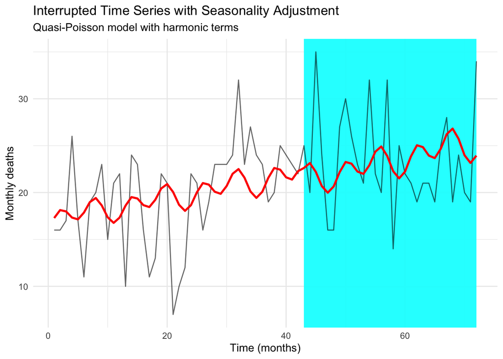

```r
mod3 <- glm(
  Deaths ~ bill8 + time +
    harmonic(month, 2, 12),
  data = monthly_f,
  family = quasipoisson(link = "log")
)


#plotting with seasonality
plot_data <- augment(mod3, type.predict = "response") %>%
  mutate(
    observed = Deaths,
    fitted = .fitted
  )

ggplot(plot_data, aes(x = time)) +

  geom_rect(
    aes(
      xmin = intervention_time,
      xmax = max(time),
      ymin = -Inf,
      ymax = Inf
    ),
    fill = "cyan",
    alpha = 0.2,
    inherit.aes = FALSE
  ) +

  geom_line(aes(y = observed), alpha = 0.6) +
  geom_line(aes(y = fitted), color = "red", linewidth = 1) +

  labs(
    x = "Time (months)",
    y = "Monthly deaths",
    title = "Interrupted Time Series with Seasonality Adjustment",
    subtitle = "Quasi-Poisson model with harmonic terms"
  ) +
  theme_minimal()
```

This provides us some interesting trends, but what we are really interested is utilizing an interrupted-ARIMA model to identify the significance of our outliers. We are going to proceed with this analysis in the rmd document called `/Scripts/Analysis`.

I am next going to replicate Figure 1 from the manuscript:

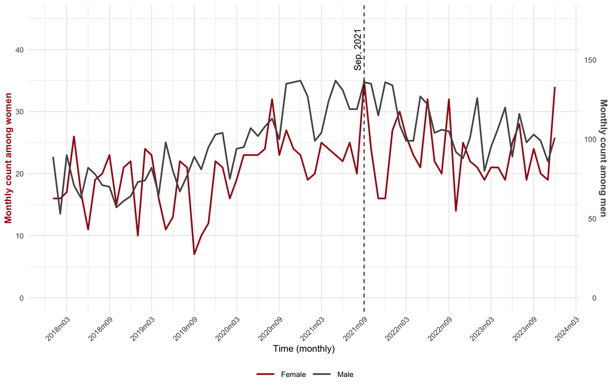

```r
# Colors
colors <- c("Female" = "#A50F15", "Male" = "#555555")

# Separate female & male
female <- monthly_all %>% filter(sex == "Female")
male   <- monthly_all %>% filter(sex == "Male")

# Scale factor for secondary axis
scale_factor <- max(female$Deaths, na.rm = TRUE) / max(male$Deaths, na.rm = TRUE)

# Vertical line time
vline_date <- as.Date("2021-09-01")

ggplot() +
  # Female line
  geom_line(data = female, aes(x = month_year, y = Deaths, color = "Female"), size = 1) +
  # Male line (scaled for secondary axis)
  geom_line(data = male, aes(x = month_year, y = Deaths * scale_factor, color = "Male"), size = 1) +

  # Vertical dashed line with label
  geom_vline(xintercept = vline_date, linetype = "dashed", color = "black") +
  annotate("text",
           x = vline_date,
           y = max(female$Deaths, na.rm = TRUE) + 5, # slightly above top
           label = "Sep, 2021",
           angle = 90,
           vjust = -0.5) +

  # Scale axes
  scale_y_continuous(
    name = "Monthly count among women",
    limits = c(0, max(female$Deaths, na.rm = TRUE) + 10),  # expand y-axis for better readability of date
    sec.axis = sec_axis(~./scale_factor,
                        name = "Monthly count among men")
  ) +

  # X-axis formatting
  scale_x_date(date_labels = "%Ym%m", date_breaks = "6 months") +

  # Line colors
  scale_color_manual(values = colors) +

  # Theme tweaks for colored axis titles
  theme_minimal(base_size = 12) +
  theme(
    legend.position = "bottom",
    legend.key.width = unit(2, "lines"),
    axis.text.x = element_text(angle = 45, hjust = 1),
    axis.title.y.left = element_text(color = colors["Female"], size = 12, face = "bold"),
    axis.title.y.right = element_text(color = colors["Male"], size = 12, face = "bold")
  ) +
  labs(x = "Time (monthly)", color = NULL)
```